# Machine Learning Analysis using Tidymodels Package (Ver. 1)

Machine Learning

Overall R code Description using Tidymodels Package for Machine Learning Analysis (Ver. 1)

Yeongeun Jeon , Jung In Seo  
04-05-2022

> Package `tidymodels (Ver 0.2.0)`는 R에서 머신러닝(Machine Learning)을 `tidyverse principle`로 수행할 수 있게끔 해주는 패키지 묶음이다. 특히, 모델링에 필요한 필수 패키지들을 대부분 포함하고 있기 때문에 데이터 전처리부터 시각화, 모델링, 예측까지 모든 과정을 `tidy framework`로 진행할 수 있다. 또한, Package `caret`을 완벽하게 대체하며 보다 더 빠르고 직관적인 코드로 모델링을 수행할 수 있다.

[출처 : https://cehs-research.github.io/PSY-6600_public/slides/ch0_getting_started_r.html#26](https://cehs-research.github.io/PSY-6600_public/slides/ch0_getting_started_r.html#26)

[출처 : https://rpubs.com/hoanganhngo610/553547](https://rpubs.com/hoanganhngo610/553547)

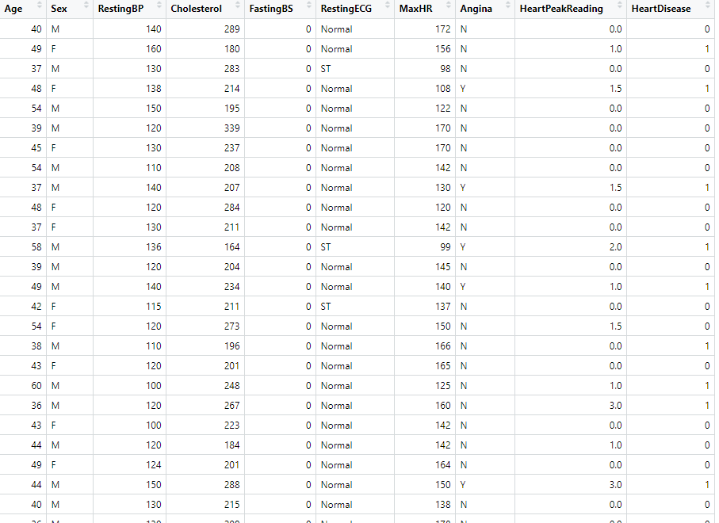

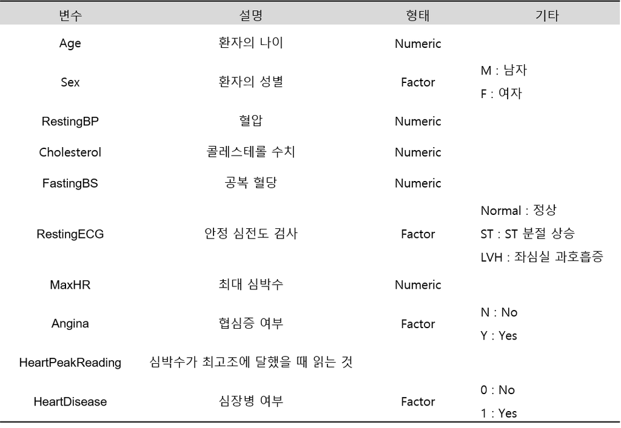

# **1. 데이터 불러오기**

```
# install.packages("tidymodels")
pacman::p_load("MLDataR",                                              # For Data
               "data.table", "magrittr",
               "tidymodels",
               "doParallel", "parallel")

registerDoParallel(cores=detectCores())


data(heartdisease)
data <- heartdisease %>%
  mutate(HeartDisease = ifelse(HeartDisease==0, "no", "yes"))


cols <- c("Sex", "RestingECG", "Angina", "HeartDisease")

data   <- data %>%
  mutate_at(cols, as.factor)                                           # 범주형 변수 변환

glimpse(data)                                                          # 데이터 구조
```

```
Rows: 918
Columns: 10
$ Age              <dbl> 40, 49, 37, 48, 54, 39, 45, 54, 37, 48, 37,~
$ Sex              <fct> M, F, M, F, M, M, F, M, M, F, F, M, M, M, F~
$ RestingBP        <dbl> 140, 160, 130, 138, 150, 120, 130, 110, 140~
$ Cholesterol      <dbl> 289, 180, 283, 214, 195, 339, 237, 208, 207~
$ FastingBS        <dbl> 0, 0, 0, 0, 0, 0, 0, 0, 0, 0, 0, 0, 0, 0, 0~
$ RestingECG       <fct> Normal, Normal, ST, Normal, Normal, Normal,~
$ MaxHR            <dbl> 172, 156, 98, 108, 122, 170, 170, 142, 130,~
$ Angina           <fct> N, N, N, Y, N, N, N, N, Y, N, N, Y, N, Y, N~
$ HeartPeakReading <dbl> 0.0, 1.0, 0.0, 1.5, 0.0, 0.0, 0.0, 0.0, 1.5~
$ HeartDisease     <fct> no, yes, no, yes, no, no, no, no, yes, no, ~
```

# **2. 데이터 분할**

- `tidymodels` 안에는 다양한 Package들이 포함되어 있는데 데이터 분할은 Package `rsample`에 있는 함수 `initial_split()`를 이용한다.

[output not shown]

# **3. 데이터 전처리**

- 데이터 전처리는 Package `recipes`를 이용한다.
- Package `recipes`의 과정은 [여기](https://www.r-bloggers.com/2019/07/how-to-use-recipes-package-from-tidymodels-for-one-hot-encoding-%F0%9F%9B%A0/)를 참조한다.
  1. 필요한 재료를 구한다.
     - 함수 `recipe()` 이용
  2. 재료에 어떤 레시피를 적용할 것인가 생각한다.
     - 함수 `step_*()` 이용
  3. 레시피를 기반으로 요리하기 전에 준비한다.
     - 함수 `prep()` 이용
  4. 준비된 레시피로 요리를 한다.
     - 함수 `juice()`와 함수 `bake()` 이용

## **3-1. 변수 정의**

- 필요한 재료를 구한다. $\rightarrow$ Target과 예측변수에 대해 함수 `recipe()`로 명시한다.

```
rec  <- recipe(HeartDisease ~ ., data = HD.train)                      # recipe(formula, data) HeartDisease -> Target, 나머지 모든 변수 -> 예측변수변수
rec
```

```
Recipe

Inputs:

      role #variables
   outcome          1
 predictor          9
```

```
summary(rec)
```

```
# A tibble: 10 x 4
   variable         type    role      source
   <chr>            <chr>   <chr>     <chr>
 1 Age              numeric predictor original
 2 Sex              nominal predictor original
 3 RestingBP        numeric predictor original
 4 Cholesterol      numeric predictor original
 5 FastingBS        numeric predictor original
 6 RestingECG       nominal predictor original
 7 MaxHR            numeric predictor original
 8 Angina           nominal predictor original
 9 HeartPeakReading numeric predictor original
10 HeartDisease     nominal outcome   original
```

## **3-2. 전처리 정의**

- 재료에 어떤 레시피를 적용할 것인가 생각한다. $\rightarrow$ 어떤 전처리 과정을 진행할 것인지 정의한다.
- 각 변수에 적용할 수 있는 전처리 함수는 [여기](https://recipes.tidymodels.org/reference/index.html)를 잠조한다.

[output not shown]

```
Recipe

Inputs:

      role #variables
   outcome          1
 predictor          9

Operations:

Centering and scaling for all_numeric_predictors()
Dummy variables from all_nominal_predictors()
```

## **3-3. 전처리 계산**

- 레시피를 기반으로 요리하기 전에 준비한다. $\rightarrow$ 위에서 정의된 전처리 과정을 데이터에 적용하기 위해 필요한 부분을 계산 또는 추정한다.
  - 예를 들어, 표준화를 위해 Training Data의 평균과 표준편차를 계산하여 저장한다.
- 함수 `prep(, retain = TRUE)`를 이용하여 전처리가 적용된 Training Data를 준비(저장)한다.

```
rec.prepped   <- prep(rec1, training = HD.train, retain = TRUE)
rec.prepped
```

```
Recipe

Inputs:

      role #variables
   outcome          1
 predictor          9

Training data contained 642 data points and no missing data.

Operations:

Centering and scaling for Age, RestingBP, Cholesterol, FastingB... [trained]
Dummy variables from Sex, RestingECG, Angina [trained]
```

## **3-4. 전처리된 데이터 생성**

- 준비된 레시피로 요리를 한다. $\rightarrow$ 전처리를 적용한 결과를 생성한다.
  - 이때, 함수 `juice()`와 함수 `bake()`를 이용한다.
    - 함수 `juice()` 오직 `Training Data에 대해서만` 적용할 수 있으며, 함수 `bake()`는 `새로운 데이터`에 적용할 때 사용한다.
- 전처리 계산에서 옵션 `retain = TRUE`를 이용하여 전처리가 적용된 Training Data를 저장했기 때문에, 함수 `juice()`를 이용하여 전처리된 Training Data를 생성한다.
  - 이것은 `bake(prep(), Training Data)`과 같다.
- Test Data에 대해서는 함수 `bake()`를 이용하여 Training Data로부터 계산된 전처리를 적용, 전처리가 적용된 Test Data를 생성한다.

```
train.prepped <- juice(rec.prepped)                                    # 전처리가 적용된 Training Data를 생성생성
test.prepped  <- bake(rec.prepped, HD.test)                            # 전처리가 적용된 Test Data를 생성생성

glimpse(train.prepped)
```

```
Rows: 642
Columns: 14
$ Age               <dbl> -1.47736664, -1.79906343, 0.02388507, -1.5~
$ RestingBP         <dbl> 0.4331599, -0.1020377, 0.9683574, -0.63723~
$ Cholesterol       <dbl> 0.802221831, 0.746860505, -0.065105609, 1.~
$ FastingBS         <dbl> -0.5445247, -0.5445247, -0.5445247, -0.544~
$ MaxHR             <dbl> 1.36842135, -1.54125781, -0.59757808, 1.28~
$ HeartPeakReading  <dbl> -0.84518925, -0.84518925, -0.84518925, -0.~
$ HeartDisease      <fct> no, no, no, no, no, no, no, no, no, no, no~
$ Sex_F             <dbl> 0, 0, 0, 0, 1, 1, 1, 1, 0, 1, 0, 0, 0, 1, ~
$ Sex_M             <dbl> 1, 1, 1, 1, 0, 0, 0, 0, 1, 0, 1, 1, 1, 0, ~
$ RestingECG_LVH    <dbl> 0, 0, 0, 0, 0, 0, 0, 0, 0, 0, 0, 0, 0, 0, ~
$ RestingECG_Normal <dbl> 1, 0, 1, 1, 1, 1, 1, 1, 1, 1, 1, 0, 1, 1, ~
$ RestingECG_ST     <dbl> 0, 1, 0, 0, 0, 0, 0, 0, 0, 0, 0, 1, 0, 0, ~
$ Angina_N          <dbl> 1, 1, 1, 1, 1, 1, 1, 1, 1, 1, 1, 0, 1, 1, ~
$ Angina_Y          <dbl> 0, 0, 0, 0, 0, 0, 0, 0, 0, 0, 0, 1, 0, 0, ~
```

```
glimpse(test.prepped)
```

```
Rows: 276
Columns: 14
$ Age               <dbl> 0.02388507, -1.79906343, -1.79906343, -1.5~
$ RestingBP         <dbl> -1.1724328, 0.4331599, -0.1020377, -0.6372~
$ Cholesterol       <dbl> 0.05484393, 0.04561704, 0.08252459, 0.0179~
$ FastingBS         <dbl> -0.5445247, -0.5445247, -0.5445247, -0.544~
$ MaxHR             <dbl> 0.188821690, -0.283018173, 0.188821690, 0.~
$ HeartPeakReading  <dbl> -0.84518925, 0.53667365, -0.84518925, -0.8~
$ HeartDisease      <fct> no, yes, no, no, yes, no, yes, yes, no, no~
$ Sex_F             <dbl> 0, 0, 1, 0, 0, 1, 0, 0, 1, 0, 0, 0, 0, 1, ~
$ Sex_M             <dbl> 1, 1, 0, 1, 1, 0, 1, 1, 0, 1, 1, 1, 1, 0, ~
$ RestingECG_LVH    <dbl> 0, 0, 0, 0, 0, 0, 0, 0, 0, 0, 0, 0, 0, 0, ~
$ RestingECG_Normal <dbl> 1, 1, 1, 1, 1, 0, 1, 1, 1, 1, 1, 0, 1, 1, ~
$ RestingECG_ST     <dbl> 0, 0, 0, 0, 0, 1, 0, 0, 0, 0, 0, 1, 0, 0, ~
$ Angina_N          <dbl> 1, 0, 1, 1, 0, 1, 1, 1, 1, 1, 1, 1, 1, 0, ~
$ Angina_Y          <dbl> 0, 1, 0, 0, 1, 0, 0, 0, 0, 0, 0, 0, 0, 1, ~
```

# **4. 모형 적합**

- 모형 적합에는 Package `parsnip`를 이용한다.

## **4-1. 모형 정의**

- 모형을 구축하기 위해 모형을 먼저 정의한다.
  - 모형을 정의하기 위해 `모형 타입(Type)`과 `모형 종류(set_mode)` 그리고 `사용할 패키지(set_engine)`가 필요하다.
    - 모형 타입 : 사용하고자하는 머신러닝 함수 정의
      - 예를 들어, Random Forest는 함수 `rand_forest()`를 사용한다.
    - 모형 종류 : Target 유형 정의
      - 분류(Classification) 또는 회귀(Regresssion) 중 하나를 선택한다.
    - 사용할 패키지 : 사용하고자하는 Package 정의
      - Random Forest는 Package `randomForest`, `ranger`, `spark`를 사용할 수 있다.
- Package `tidymodels`에서 사용할 수 있는 모형은 [여기](https://www.tidymodels.org/find/parsnip/)를 참조한다.

[output not shown]

```
Random Forest Model Specification (classification)

Main Arguments:
  mtry = 12
  trees = 100

Engine-Specific Arguments:
  importance = TRUE

Computational engine: randomForest

Model fit template:
randomForest::randomForest(x = missing_arg(), y = missing_arg(),
    mtry = min_cols(~12, x), ntree = 100, importance = TRUE)
```

`Caution!` 함수 `translate()`를 통해 위에서 정의한 “rf.mod”가 실제로 Package `randomForest`의 함수 `randomForest()`에 어떻게 적용되는지 확인할 수 있다.

- `?rand_forest`를 통해서 모형의 모수를 확인할 수 있다.
- Random Forest는 `mtry`, `trees`, `min_n`을 모수로 가진다.
  - `mtry` : 노드를 분할할 때 랜덤하게 선택되는 후보 예측변수 개수
  - `trees` : 생성하고자 하는 트리의 개수
  - `min_n` : 터미널 노드(Terminal Node)의 최소 개수

```
 ?rand_forest                                                         # 모형 특정 함수 안에 어떤 모수가 있는 지 확인 가능
```

## **4-2. 모형 적합**

[output not shown]

```
parsnip model object


Call:
 randomForest(x = maybe_data_frame(x), y = y, ntree = ~100, mtry = min_cols(~12,      x), importance = ~TRUE)
               Type of random forest: classification
                     Number of trees: 100
No. of variables tried at each split: 12

        OOB estimate of  error rate: 19.63%
Confusion matrix:
     no yes class.error
no  226  61   0.2125436
yes  65 290   0.1830986
```

# **5. 예측**

- 예측 및 모형 평가는 4-2. 모형 적합에서 얻은 적합 결과 `rf.fit`을 이용한다.

## **5-1. 예측 클래스**

```
rf.pred.class <- predict(rf.fit, test.prepped)
rf.pred.class
```

```
# A tibble: 276 x 1
   .pred_class
   <fct>
 1 no
 2 yes
 3 no
 4 no
 5 yes
 6 no
 7 yes
 8 no
 9 no
10 no
# ... with 266 more rows
```

## **5-2. 예측 확률**

```
rf.pred.prob <- predict(rf.fit, test.prepped, type = "prob")
rf.pred.prob
```

```
# A tibble: 276 x 2
   .pred_no .pred_yes
      <dbl>     <dbl>
 1     0.91      0.09
 2     0.3       0.7
 3     0.99      0.01
 4     0.95      0.05
 5     0.29      0.71
 6     0.97      0.03
 7     0.45      0.55
 8     0.68      0.32
 9     0.99      0.01
10     0.95      0.05
# ... with 266 more rows
```

## **5-3. 모든 예측 결과 출력**

- 함수 `augment()`를 이용해서 예측 클래스와 예측 확률을 포함한 결과를 한 번에 출력할 수 있다.

```
rf.pred <- augment(rf.fit, test.prepped)
rf.pred
```

```
# A tibble: 276 x 17
       Age RestingBP Cholesterol FastingBS    MaxHR HeartPeakReading
     <dbl>     <dbl>       <dbl>     <dbl>    <dbl>            <dbl>
 1  0.0239    -1.17       0.0548    -0.545  0.189            -0.845
 2 -1.80       0.433      0.0456    -0.545 -0.283             0.537
 3 -1.80      -0.102      0.0825    -0.545  0.189            -0.845
 4 -1.58      -0.637      0.0179    -0.545  0.307            -0.845
 5 -0.512      0.433      0.295     -0.545  0.110             0.0761
 6 -1.26      -0.905      0.0825    -0.545 -0.00778          -0.845
 7  0.667     -1.71       0.424     -0.545 -0.480             0.0761
 8 -1.91      -0.637      0.599     -0.545  0.897             1.92
 9 -1.16      -1.71       0.193     -0.545  0.189            -0.845
10 -1.91      -0.102      0.0641    -0.545  1.60             -0.845
# ... with 266 more rows, and 11 more variables: HeartDisease <fct>,
#   Sex_F <dbl>, Sex_M <dbl>, RestingECG_LVH <dbl>,
#   RestingECG_Normal <dbl>, RestingECG_ST <dbl>, Angina_N <dbl>,
#   Angina_Y <dbl>, .pred_class <fct>, .pred_no <dbl>,
#   .pred_yes <dbl>
```

```
rf.pred %>%
  select(contains(".pred"))                                      # 예측 결과들만 추출
```

```
# A tibble: 276 x 3
   .pred_class .pred_no .pred_yes
   <fct>          <dbl>     <dbl>
 1 no              0.91      0.09
 2 yes             0.3       0.7
 3 no              0.99      0.01
 4 no              0.95      0.05
 5 yes             0.29      0.71
 6 no              0.97      0.03
 7 yes             0.45      0.55
 8 no              0.68      0.32
 9 no              0.99      0.01
10 no              0.95      0.05
# ... with 266 more rows
```

# **6. 모형 평가**

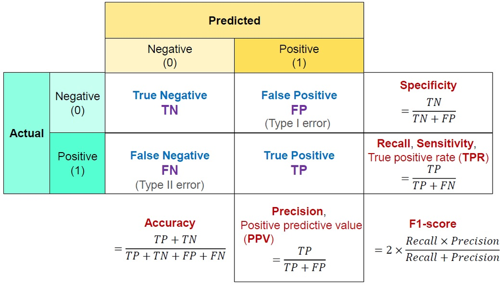

[출처 : https://velog.io/@hajeongjj/Eval-Metrics](https://velog.io/@hajeongjj/Eval-Metrics)

- 분류와 회귀에 사용될 수 있는 척도는 [여기](https://yardstick.tidymodels.org/articles/metric-types.html)를 참조한다.
- 자세한 예제는 [여기](https://www.tmwr.org/performance.html#binary-classification-metrics)를 참조한다.

## **6-1. 척도**

### **6-1-1. ConfusionMatrix**

```
conf_mat(rf.pred, truth = HeartDisease, estimate = .pred_class)        # truth : 실제 클래스,  estimate : 예측 클래스 클래스
```

```
          Truth
Prediction  no yes
       no   97  28
       yes  26 125
```

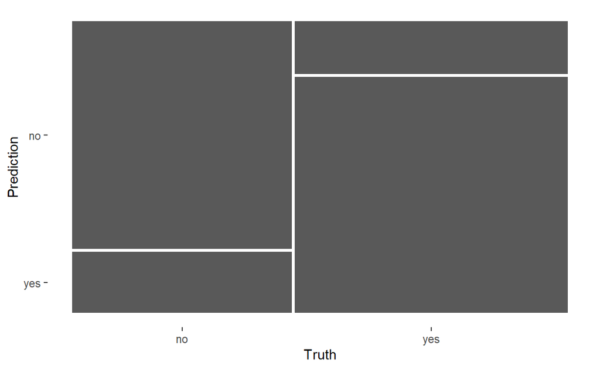

```
conf_mat(rf.pred, truth = HeartDisease, estimate = .pred_class) %>%
  autoplot(type = "mosaic")                                            # autoplot(type = "heatmap")
```

### **6-1-2. Accuracy**

```
accuracy(rf.pred, truth = HeartDisease, estimate = .pred_class)        # truth : 실제 클래스,  estimate : 예측 클래스 클래스
```

```
# A tibble: 1 x 3
  .metric  .estimator .estimate
  <chr>    <chr>          <dbl>
1 accuracy binary         0.804
```

### **6-1-3. 여러 척도를 한 번에 나타내기**

- 함수 `metric_set()`를 통해 여러 척도를 한 번에 나타낼 수 있다. 함수의 자세한 옵션은 [여기](https://yardstick.tidymodels.org/articles/metric-types.html)를 참조한다.

```
classification_metrics <- metric_set(accuracy, mcc,
                                     f_meas, kap,
                                     sens, spec, roc_auc)              # Test Data에 대한 Assessment Measure
classification_metrics(rf.pred,
                       truth = HeartDisease, estimate = .pred_class,   # truth : 실제 클래스, estimate : 예측 클래스 클래스
                       .pred_yes, event_level = "second")              # For roc_auc
```

```
# A tibble: 7 x 3
  .metric  .estimator .estimate
  <chr>    <chr>          <dbl>
1 accuracy binary         0.804
2 mcc      binary         0.605
3 f_meas   binary         0.822
4 kap      binary         0.605
5 sens     binary         0.817
6 spec     binary         0.789
7 roc_auc  binary         0.869
```

`Caution!` “ROC AUC”를 계산하기 위해서는 관심 클래스에 대한 예측 확률이 필요하다. 예제 데이터에서 관심 클래스는 “yes”이므로 “yes”에 대한 예측 확률 결과인 `.pred_yes`가 사용되었다. 또한, Target인 “HeartDisease” 변수의 유형을 “Factor” 변환하면 알파벳순으로 클래스를 부여하기 때문에 관심 클래스 “yes”가 두 번째 클래스가 된다. 따라서 옵션 `event_level = "second"`을 사용하여 관심 클래스가 “yes”임을 명시해주어야 한다.

## **6-2. 그래프**

`Caution!` 함수 “roc_curve(), gain_curve(), lift_curve(), pr_curve()”에서는 첫번째 클래스(Level)를 관심 클래스로 인식한다. R에서는 함수 `Factor()`를 이용하여 변수 유형을 변환하면 알파벳순(영어) 또는 오름차순(숫자)으로 클래스를 부여하므로 “HeartDisease” 변수의 경우 “no”가 첫번째 클래스가 되고 “yes”가 두번째 클래스가 된다. 따라서, 예제 데이터에서 관심 클래스는 “yes”이기 때문에 옵션 `event_level = "second"`을 사용하여 관심 클래스가 “yes”임을 명시해주어야 한다.

### **6-2-1. ROC Curve**

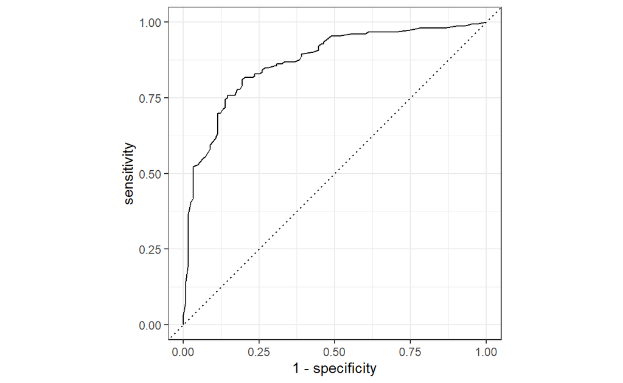

```
rf.pred %>%
  roc_curve(truth = HeartDisease, .pred_yes,                           # truth : 실제 클래스,  관심 클래스 예측 확률  확률
            event_level = "second") %>%
  autoplot()
```

### **6-2-2. Gain Curve**

- Gain Curve는 관심 클래스 대비 해당 분위수에서의 관심 클래스 비율을 나타낸 그래프이다.

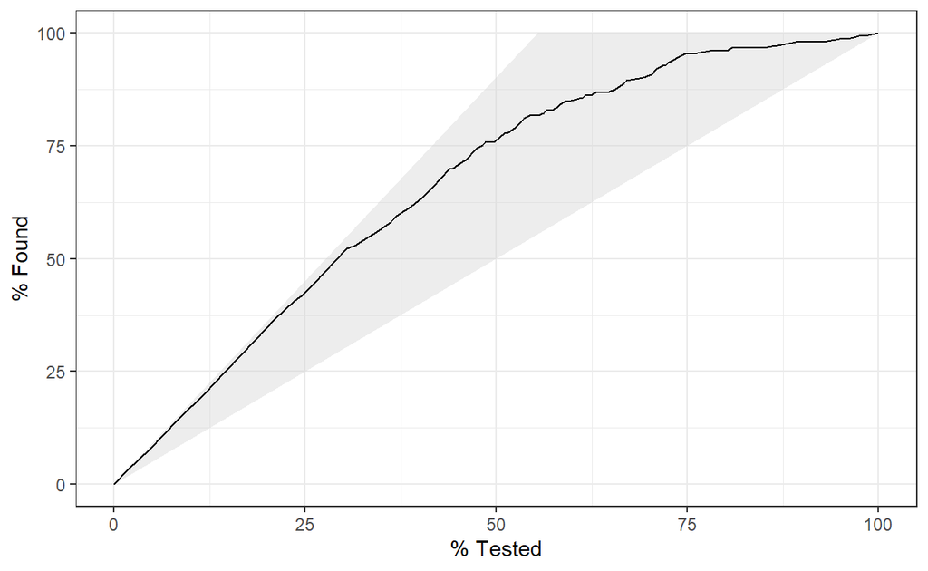

```
rf.pred %>%
  gain_curve(truth = HeartDisease, .pred_yes,                          # truth : 실제 클래스,  관심 클래스 예측 확률  확률
             event_level = "second") %>%
  autoplot()
```

`Caution!` 관심 클래스의 예측 확률을 내림차순으로 정렬한 후 그래프로 나타낸다. 함수 `gain_curve()`에 대한 자세한 설명은 [여기](https://yardstick.tidymodels.org/reference/gain_curve.html)를 참조한다.  
`Result!` x축인 `%Tested`은 Test Data의 분위수이며, y축인 `%Found`은 관심 클래스 대비 해당 분위수에서의 관심 클래스 비율(즉, 해당 분위수에서의 관심 클래스 빈도 / Test Data에서의 관심 클래스 빈도)을 나타낸다. 그리고 `회색 영역의 삼각형`은 ‘Perfect’ Gain Curve으로 정확도가 100%인 모형에 대한 Gain Curve이다.

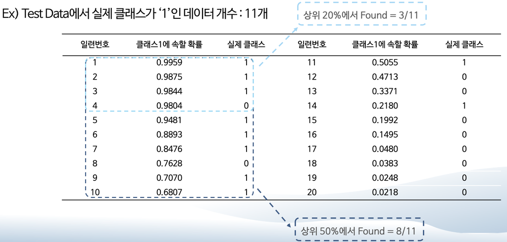

### **6-2-3. Lift Curve**

- Lift Curve는 전체 반응률 대비 해당 분위수의 반응률를 나타낸 그래프이다.

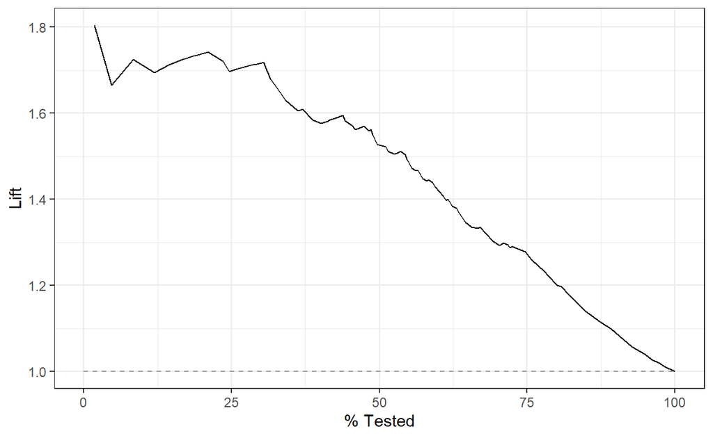

```
rf.pred %>%
  lift_curve(truth = HeartDisease, .pred_yes,                          # truth : 실제 클래스,  관심 클래스 예측 확률  확률
             event_level = "second") %>%
  autoplot()
```

`Caution!` 관심 클래스의 예측 확률을 내림차순으로 정렬한 후 그래프로 나타낸다. 함수 `lift_curve()`에 대한 자세한 설명은 [여기](https://yardstick.tidymodels.org/reference/lift_curve.html)를 참조한다.  
`Result!` x축인 `%Tested`은 Test Data의 분위수이며, y축인 `Lift`는 전체 관심 클래스 비율 대비 해당 분위수의 관심 클래스 비율(함수 `gain_curve()`의 `y축 %Found`)을 `x축 %Tested`으로 나눈 값(함수 `gain_curve()`의 `y축 %Found`/`x축 %Tested`)을 나타낸다.

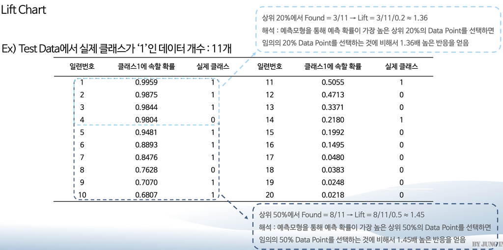

### **6-2-4. Precision Recall Curve**

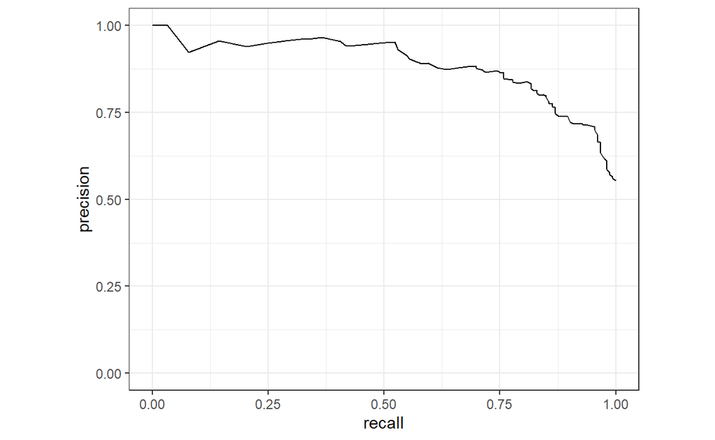

```
rf.pred %>%
  pr_curve(truth = HeartDisease, .pred_yes,                            # truth : 실제 클래스,  관심 클래스 예측 확률  확률
           event_level = "second") %>%
  autoplot()
```

# **7. Resampling 방법**

- Resampling 방법은 Training Data의 일부를 모형 구축에 사용하고 구축된 모형을 평가하기 위해 또 다른 일부를 사용하는 과정을 반복한다. 이러한 방법은 모형의 성능을 측정하기 위해 사용되며, 모수 튜닝에서 최적의 모수 조합을 찾을 때 사용한다.

[figure not shown]

[출처 : https://www.tmwr.org/resampling.html](https://www.tmwr.org/resampling.html)

- 위의 그림처럼 Training Data를 `Analysis` 그룹과 `Assessment` 그룹으로 분할한다.
  - `Analysis` 그룹 : 모형을 구축하기 위해 사용하는 데이터셋
  - `Assessment` 그룹 : 구축된 모형을 평가하기 위해 사용하는 데이터셋
- 만약, Resampling 방법을 통해 20개의 모형이 구축되면 모형 평가 척도값도 20개가 나온다.
- 이러한 경우, 최종 모형 평가 척도값은 20개의 평균을 사용한다.
  - 이 방법은 일반화 특성이 매우 우수한 것으로 알려져 있다.

## **7-1. K-Fold Cross-Vailidation**

[figure not shown]

[출처 : https://www.tmwr.org/resampling.html](https://www.tmwr.org/resampling.html)

- K-Fold Cross Validation은 Training Data를 K개의 Fold로 나눈 후, K-1개의 Fold(`Analysis` 그룹)를 이용하여 모형을 구축하고 1개의 Fold(`Assessment` 그룹)를 이용하여 구축된 모형을 평가한다.
- 총 K번을 반복하기 때문에 K개의 평가 척도값이 계산된다.

```
set.seed(100)
vfold_cv(data, v)
```

- `data` : Data Frame 형태의 (Training) Data
- `v` : Fold 개수

## **7-2. Repeated K-Fold Cross-Vailidation**

- K-Fold Cross-Vailidation를 반복하는 Resampling 방법이다.

```
vfold_cv(data, v, repeats)
```

- `data` : Data Frame 형태의 (Training) Data
- `v` : Fold 개수
- `repeats` : K-Fold Cross-Vailidation 반복 수

## **7-3. Leave-One-Out Cross-Validation**

- Training Data에서 오직 한 개의 Data Point만을 이용하여 평가하고 나머지 Data Point들을 이용하여 모형을 구축한다.
- 총 데이터 개수만큼 반복하기 때문에 평가 척도값도 데이터 개수만큼 계산된다.

```
loo_cv(data)
```

- `data` : Data Frame 형태의 (Training) Data

## **7-4. Monte Carlo Cross-Validation**

- Training Data를 랜덤하게 `Analysis` 그룹과 `Assessment` 그룹으로 나눈다.
- 따라서, 한 개의 Data Point가 `Assessment` 그룹으로 여러 번 선택될 수 있다.

```
mc_cv(data, prop, times)
```

- `data` : Data Frame 형태의 (Training) Data
- `prop` : `Analysis` 그룹의 비율
- `times` : Resampling 반복 수

## **7-5. Validation Set**

[figure not shown]

[출처 : https://www.tmwr.org/resampling.html](https://www.tmwr.org/resampling.html)

- 전체 Data를 Test Data와 Not Test Data로 나누고, Not Test Data는 `Training Data`와 `Validation Data`로 나눈다.
  - `Training Data` : 모형을 구축하기 위해 사용하는 데이터셋
  - `Validation Data` : 구축된 모형을 평가하기 위해 사용하는 데이터셋

```
validation_split(data, prop)
```

- `data` : Data Frame 형태의 (Not Test) Data
- `prop` : `Training Data`의 비율

## **7-6. Bootstrapping**

- Training Data에서 중복을 허용하면서 랜덤하게 Training Data와 똑같은 크기의 `Analysis` 그룹을 만든다.
  - 중복을 허용했기 때문에, `Analysis` 그룹에 한 개의 Data Point가 여러 번 선택될 수 있다.
- `Analysis` 그룹에 포함되지 않은 Data Point는 `Assessment` 그룹으로 분류되어 구축된 모형을 평가하는 데 사용된다.

```
bootstraps(data, times)
```

- `data` : Data Frame 형태의 (Training) Data
- `times` : Resampling 반복 수

## **7-7. Resampling 방법을 이용한 모형 적합**

- 예를 위해, 위에서 소개한 Resampling 방법 중 가장 많이 사용되는 K-Fold Cross-Validation을 이용한다.

`Caution!` Resampling 방법을 통해 계산된 `Assessment` 그룹의 평가 척도값이 Workflow를 사용했을 때(tidymodels_Ver.2)와 결과가 다르다. 그래서, 모수 튜닝을 할 때, Workflow를 사용할 때와 최적의 모수 조합이 다를 수 있다.

### **7-7-1. Resampling 방법 정의**

```
set.seed(100)                                                          # seed 고정
train.fold <- vfold_cv(train.prepped, v = 5)
train.fold
```

```
#  5-fold cross-validation
# A tibble: 5 x 2
  splits            id
  <list>            <chr>
1 <split [513/129]> Fold1
2 <split [513/129]> Fold2
3 <split [514/128]> Fold3
4 <split [514/128]> Fold4
5 <split [514/128]> Fold5
```

`Caution!` 데이터를 먼저 5개의 Fold로 나눈 후, `Analysis` 그룹의 Dataset(4개의 Fold에 속한 513명의 환자)을 이용하여 모형을 구축하고 `Assessment` 그룹의 Dataset(1개의 Fold에 속한 129명의 환자)을 이용하여 구축된 모형을 평가한다.

### **7-7-2. 모형 적합**

- Resampling 방법을 적용한 결과는 함수 `fit_resamples()`를 이용하여 확인할 수 있다.

```
set.seed(100)
rf.fit.rs <- fit_resamples(object = rf.mod,                            # 4-1에서 정의의
                           preprocessor = HeartDisease ~ .,            # preprocessor : Formular / Recipe
                           resamples = train.fold)                     # 7-7-1에서 정의 : Resampling 방법 적용

rf.fit.rs
```

```
# Resampling results
# 5-fold cross-validation
# A tibble: 5 x 4
  splits            id    .metrics         .notes
  <list>            <chr> <list>           <list>
1 <split [513/129]> Fold1 <tibble [2 x 4]> <tibble [0 x 3]>
2 <split [513/129]> Fold2 <tibble [2 x 4]> <tibble [0 x 3]>
3 <split [514/128]> Fold3 <tibble [2 x 4]> <tibble [0 x 3]>
4 <split [514/128]> Fold4 <tibble [2 x 4]> <tibble [0 x 3]>
5 <split [514/128]> Fold5 <tibble [2 x 4]> <tibble [0 x 3]>
```

`Result!` `.metrics`열은 `Assessment` 그룹의 평가 척도값이 포함되어 있으며, `.notes`열은 Resampling 동안에 생성되는 에러나 경고를 포함한다.

[output not shown]

```
# A tibble: 2 x 6
  .metric  .estimator  mean     n std_err .config
  <chr>    <chr>      <dbl> <int>   <dbl> <fct>
1 accuracy binary     0.812     5 0.00282 Preprocessor1_Model1
2 roc_auc  binary     0.865     5 0.00348 Preprocessor1_Model1
```

```
# 각 Assessment 그룹에 대한 Assessment Measuree
collect_metrics(rf.fit.rs, summarize = FALSE)
```

```
# A tibble: 10 x 5
   id    .metric  .estimator .estimate .config
   <chr> <chr>    <chr>          <dbl> <fct>
 1 Fold1 accuracy binary         0.806 Preprocessor1_Model1
 2 Fold1 roc_auc  binary         0.867 Preprocessor1_Model1
 3 Fold2 accuracy binary         0.814 Preprocessor1_Model1
 4 Fold2 roc_auc  binary         0.875 Preprocessor1_Model1
 5 Fold3 accuracy binary         0.805 Preprocessor1_Model1
 6 Fold3 roc_auc  binary         0.869 Preprocessor1_Model1
 7 Fold4 accuracy binary         0.812 Preprocessor1_Model1
 8 Fold4 roc_auc  binary         0.855 Preprocessor1_Model1
 9 Fold5 accuracy binary         0.820 Preprocessor1_Model1
10 Fold5 roc_auc  binary         0.860 Preprocessor1_Model1
```

`Caution!` 함수 `collect_metrics(, summarize = FALSE)`을 이용하면 각 `Assessment` 그룹에 대한 모형 평가 척도값을 확인할 수 있다.

### **7-7-3. 각 Fold에 대한 결과**

- 함수 `control_resamples()`를 이용하여 `Assessment` 그룹에 대한 예측 결과를 저장할 수 있다.

[output not shown]

```
# A tibble: 642 x 7
   id    .pred_no .pred_yes  .row .pred_class HeartDisease .config
   <chr>    <dbl>     <dbl> <int> <fct>       <fct>        <fct>
 1 Fold1     0.89      0.11     5 no          no           Preprocess~
 2 Fold1     1         0       11 no          no           Preprocess~
 3 Fold1     0.66      0.34    13 no          no           Preprocess~
 4 Fold1     0.55      0.45    14 no          no           Preprocess~
 5 Fold1     1         0       22 no          no           Preprocess~
 6 Fold1     0.98      0.02    28 no          no           Preprocess~
 7 Fold1     0.86      0.14    33 no          no           Preprocess~
 8 Fold1     0.81      0.19    39 no          no           Preprocess~
 9 Fold1     0.87      0.13    46 no          no           Preprocess~
10 Fold1     0.92      0.08    52 no          no           Preprocess~
# ... with 632 more rows
```

`Caution!` 함수 `collect_predictions()`을 이용하면 각 `Assessment` 그룹에 대한 예측 결과를 확인할 수 있다.

# **8. 모수 튜닝**

- 모형을 구축하기 위해서는 모수를 먼저 명시해줘야 한다.
- 최적의 모수 조합을 찾기 위해, 후보 모수 집합에 대해 Resampling 방법을 적용하여 각 후보 모수 집합에 대한 모형을 평가한다.

## **8-1. Regular Grid**

- Package `dials`에 있는 함수 `grid_regular()`를 이용한다.
- 모수별로 후보 모수값들을 지정한 후 조합을 생성한다.
  - 예를 들어, Random Forest의 경우 `mtry = 2, 4`, `trees = 100, 200`, `min_n = 5, 6` 처럼 모수별로 후보 모수값을 먼저 지정한 후 이에 대한 조합 {(`mtry`, `trees`, `min_n`) : (2, 100, 5), (2, 100, 6), (2, 200, 5), (2, 200, 6), (4, 100, 5), (4, 100, 6), (4, 200, 5), (4, 200, 6)}을 생성한다.

```
grid_regular(x, levels)
```

- `x` : param 객체, 리스트 또는 모수
- `levels` : 각 모수에 대한 후보 개수

## **8-2. Irregular Grid**

### **8-2-1. Random Grid**

- 후보 모수 집합을 랜덤하게 생성한다.

```
grid_random(x, size)
```

- `x` : param 객체, 리스트 또는 모수
- `size` : 후보 모수 집합 개수

### **8-2-2. Latin Hypercube**

- Random Grid와 같이 후보 모수 조합을 랜덤하게 생성을 하지만, 모수 공간이 중복될 가능성이 가장 낮은 랜덤 조합을 찾기 때문에 Random Grid보다 더 효율적이다.

```
grid_latin_hypercube(x, size)
```

- `x` : param 객체, 리스트 또는 모수
- `size` : 후보 모수 집합 개수

## **8-3. Expand Grid**

- 모수별로 직접 후보값을 할당한다.

```
expand.grid(...)
```

- `...` : 모수 이름과 후보값을 벡터 또는 범주로 지정

## **8-4. 모수 튜닝을 이용한 모형 적합**

- Latin Hypercube로 후보 모수 집합을 랜덤하게 생성한 후, K-Fold Cross-Validation을 이용하여 각 후보 모수의 조합에 대해 평가한다.

### **8-4-1. 모형 정의**

- 모형에서 튜닝하고 싶은 모수는 함수 `tune()`으로 지정한다.

[output not shown]

### **8-4-2. 모수 범위 확인**

- 함수 `extract_parameter_set_dials()`를 이용하여 모수들의 정보를 확인한다.

```
rf.param    <- extract_parameter_set_dials(rf.tune.mod)
rf.param
```

```
Collection of 2 parameters for tuning

 identifier  type    object
       mtry  mtry nparam[?]
      trees trees nparam[+]

Model parameters needing finalization:
   # Randomly Selected Predictors ('mtry')

See `?dials::finalize` or `?dials::update.parameters` for more information.
```

`Result!` `object`열에서 `nparam`은 모수값이 수치형임을 나타낸다. 또한, `nparam[+]`는 해당 모수의 범위가 명확하게 주어졌음을 의미하고, `nparam[?]`는 모수의 범위에서 상한 또는 하한의 값이 명확하지 않다는 것을 의미한다. 이러한 경우, 상한 또는 하한의 값을 명확하게 결정하여야 한다.

```
rf.param %>%
  extract_parameter_dials("mtry")
```

```
# Randomly Selected Predictors (quantitative)
Range: [1, ?]
```

`Caution!` 함수 `extract_parameter_dials()`를 이용하여 모수 범위를 자세히 확인할 수 있다.  
`Result!` `mtry`의 상한이 `?`이므로 상한값을 결정하여야 한다.

### **8-4-3. 모수 범위 수정**

- 모수의 범위를 수정하는 방법은 두 가지가 있다.
  1. 함수 `update()`를 이용하여 상한값과 하한값을 직접 할당한다.
     - `update(모수 이름 = 모수 이름(c(하한, 상한)))`
  2. 함수 [`finalize()`](https://dials.tidymodels.org/reference/finalize.html)를 이용하여 데이터셋을 기반으로 한 자동화 방법을 통해 상한값과 하한값을 결정한다.

[output not shown]

```
# Randomly Selected Predictors (quantitative)
Range: [1, 13]
```

`Result!` `mtry`의 상한이 `13`으로 수정되었다.

### **8-4-4. 후보 모수 집합에 대한 모형 평가**

- 함수 `tune_grid()`를 이용하여 각 후보 모수 조합에 대한 모형 평가를 한다.
- 예를 위해, 각 후보 모수 조합에 대해 5-Cross-Validation을 적용하여 모형 평가를 한다.

[output not shown]

```
# Tuning results
# 5-fold cross-validation
# A tibble: 5 x 5
  splits            id    .metrics          .notes   .predictions
  <list>            <chr> <list>            <list>   <list>
1 <split [513/129]> Fold1 <tibble [20 x 6]> <tibble> <tibble>
2 <split [513/129]> Fold2 <tibble [20 x 6]> <tibble> <tibble>
3 <split [514/128]> Fold3 <tibble [20 x 6]> <tibble> <tibble>
4 <split [514/128]> Fold4 <tibble [20 x 6]> <tibble> <tibble>
5 <split [514/128]> Fold5 <tibble [20 x 6]> <tibble> <tibble>
```

[output not shown]

```
# A tibble: 20 x 8
    mtry trees .metric  .estimator  mean     n std_err .config
   <int> <int> <chr>    <chr>      <dbl> <int>   <dbl> <fct>
 1     6  1363 accuracy binary     0.819     5 0.00855 Preprocessor1_~
 2     6  1363 roc_auc  binary     0.870     5 0.00556 Preprocessor1_~
 3     4  1791 accuracy binary     0.821     5 0.0112  Preprocessor1_~
 4     4  1791 roc_auc  binary     0.873     5 0.00776 Preprocessor1_~
 5     8  1010 accuracy binary     0.819     5 0.0102  Preprocessor1_~
 6     8  1010 roc_auc  binary     0.868     5 0.00486 Preprocessor1_~
 7     2   572 accuracy binary     0.827     5 0.0161  Preprocessor1_~
 8     2   572 roc_auc  binary     0.879     5 0.00892 Preprocessor1_~
 9     8   333 accuracy binary     0.810     5 0.00871 Preprocessor1_~
10     8   333 roc_auc  binary     0.868     5 0.00444 Preprocessor1_~
11    10  1533 accuracy binary     0.810     5 0.00817 Preprocessor1_~
12    10  1533 roc_auc  binary     0.866     5 0.00406 Preprocessor1_~
13     2   681 accuracy binary     0.829     5 0.0162  Preprocessor1_~
14     2   681 roc_auc  binary     0.879     5 0.00893 Preprocessor1_~
15    11   151 accuracy binary     0.813     5 0.00722 Preprocessor1_~
16    11   151 roc_auc  binary     0.861     5 0.00423 Preprocessor1_~
17    13  1882 accuracy binary     0.812     5 0.00473 Preprocessor1_~
18    13  1882 roc_auc  binary     0.863     5 0.00429 Preprocessor1_~
19     5   938 accuracy binary     0.821     5 0.00844 Preprocessor1_~
20     5   938 roc_auc  binary     0.871     5 0.00655 Preprocessor1_~
```

`Result!` 각 후보 모수 조합별로 성능을 확인할 수 있다. 평가 척도는 기본적으로 “Accuracy”와 “ROC AUC”이다.

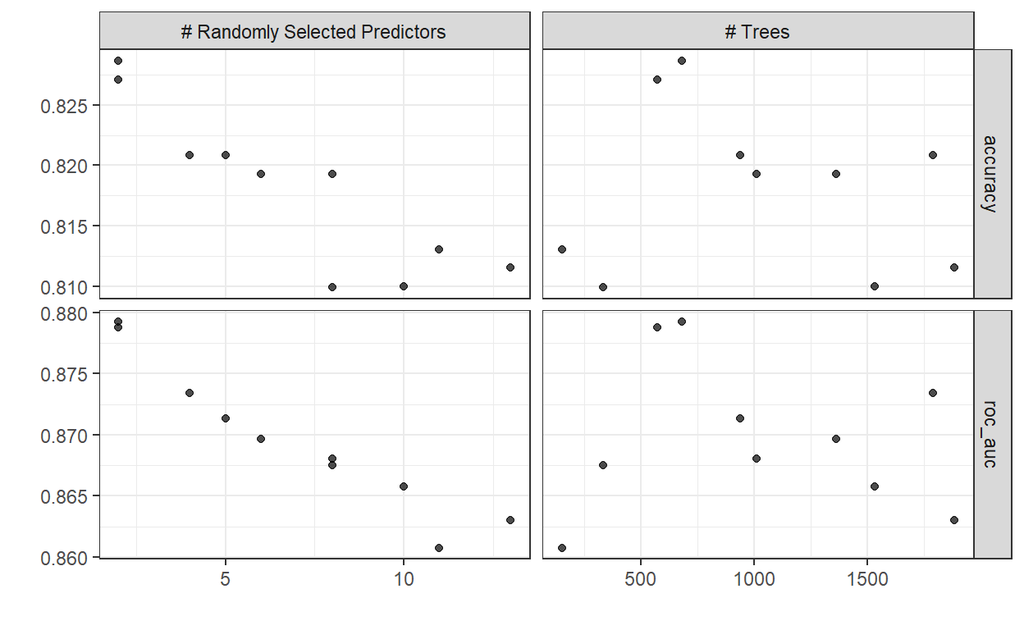

```
# 그래프
autoplot(rf.tune.fit) +
  scale_color_viridis_d(direction = -1) +
  theme(legend.position = "top") +
  theme_bw()
```

### **8-4-5. 최적의 모수 조합 확인**

- 함수 `show_best()`를 이용하여 예측 성능이 좋은 모형을 `내림차순`으로 확인할 수 있다.
- 함수 `select_best()`를 이용하여 성능이 `가장 좋은` 최적의 모수 조합을 확인할 수 있다.
- 아래 예제는 “ROC AUC”를 기준으로 그 결과를 살펴본다.

[output not shown]

```
# A tibble: 5 x 8
   mtry trees .metric .estimator  mean     n std_err .config
  <int> <int> <chr>   <chr>      <dbl> <int>   <dbl> <fct>
1     2   681 roc_auc binary     0.879     5 0.00893 Preprocessor1_Mo~
2     2   572 roc_auc binary     0.879     5 0.00892 Preprocessor1_Mo~
3     4  1791 roc_auc binary     0.873     5 0.00776 Preprocessor1_Mo~
4     5   938 roc_auc binary     0.871     5 0.00655 Preprocessor1_Mo~
5     6  1363 roc_auc binary     0.870     5 0.00556 Preprocessor1_Mo~
```

[output not shown]

```
# A tibble: 1 x 3
   mtry trees .config
  <int> <int> <fct>
1     2   681 Preprocessor1_Model07
```

`Result!` `mtry = 2`, `trees = 681`일 때 “ROC AUC” 측면에서 모형의 예측 성능이 가장 좋다.

### **8-4-6. 최적의 모수 조합을 이용한 모형 적합**

- 위에서 찾은 최적의 모수 조합을 이용하여 모형을 구축한다.
- 함수 `finalize_model()`을 이용하여 8-4-1에서 정의한 “rf.tune.mod”을 최적의 모수 조합을 가지는 “모형”으로 업데이트한다.

[output not shown]

```
Random Forest Model Specification (classification)

Main Arguments:
  mtry = 2
  trees = 681

Computational engine: randomForest
```

[output not shown]

```
parsnip model object


Call:
 randomForest(x = maybe_data_frame(x), y = y, ntree = ~681L, mtry = min_cols(~2L,      x))
               Type of random forest: classification
                     Number of trees: 681
No. of variables tried at each split: 2

        OOB estimate of  error rate: 17.45%
Confusion matrix:
     no yes class.error
no  234  53   0.1846690
yes  59 296   0.1661972
```

[output not shown]

```
Call:
 randomForest(x = maybe_data_frame(x), y = y, ntree = ~681L, mtry = min_cols(~2L,      x))
               Type of random forest: classification
                     Number of trees: 681
No. of variables tried at each split: 2

        OOB estimate of  error rate: 17.45%
Confusion matrix:
     no yes class.error
no  234  53   0.1846690
yes  59 296   0.1661972
```

## **8-5. 예측**

```
pred <- augment(final.rf.fit, test.prepped)                             # predict(final.rf.fit, test.prepped)
pred
```

```
# A tibble: 276 x 17
       Age RestingBP Cholesterol FastingBS    MaxHR HeartPeakReading
     <dbl>     <dbl>       <dbl>     <dbl>    <dbl>            <dbl>
 1  0.0239    -1.17       0.0548    -0.545  0.189            -0.845
 2 -1.80       0.433      0.0456    -0.545 -0.283             0.537
 3 -1.80      -0.102      0.0825    -0.545  0.189            -0.845
 4 -1.58      -0.637      0.0179    -0.545  0.307            -0.845
 5 -0.512      0.433      0.295     -0.545  0.110             0.0761
 6 -1.26      -0.905      0.0825    -0.545 -0.00778          -0.845
 7  0.667     -1.71       0.424     -0.545 -0.480             0.0761
 8 -1.91      -0.637      0.599     -0.545  0.897             1.92
 9 -1.16      -1.71       0.193     -0.545  0.189            -0.845
10 -1.91      -0.102      0.0641    -0.545  1.60             -0.845
# ... with 266 more rows, and 11 more variables: HeartDisease <fct>,
#   Sex_F <dbl>, Sex_M <dbl>, RestingECG_LVH <dbl>,
#   RestingECG_Normal <dbl>, RestingECG_ST <dbl>, Angina_N <dbl>,
#   Angina_Y <dbl>, .pred_class <fct>, .pred_no <dbl>,
#   .pred_yes <dbl>
```

## **8-6. 모형 적합과 예측을 한 번에 하기**

- 함수 `last_fit()`를 이용하여 최적의 모수 조합에 대해 Training Data를 이용한 모형 적합과 Test Data에 대한 예측을 한 번에 수행할 수 있다.

```
# Ref. https://github.com/tidymodels/tune/issues/300 (last_fit과 fit의 결과가 다름))
#      https://github.com/tidymodels/tune/pull/323 (last_fit seed X)

final.rf.last <- last_fit(final.rf,
                          preprocessor = HeartDisease ~ .,             # preprocessor : Formular / Recipe
                          split = data.split)
final.rf.last
```

```
# Resampling results
# Manual resampling
# A tibble: 1 x 6
  splits            id       .metrics .notes   .predictions .workflow
  <list>            <chr>    <list>   <list>   <list>       <list>
1 <split [642/276]> train/t~ <tibble> <tibble> <tibble>     <workflow>
```

[output not shown]

```
Call:
 randomForest(x = maybe_data_frame(x), y = y, ntree = ~681L, mtry = min_cols(~2L,      x))
               Type of random forest: classification
                     Number of trees: 681
No. of variables tried at each split: 2

        OOB estimate of  error rate: 17.45%
Confusion matrix:
     no yes class.error
no  231  56   0.1951220
yes  56 299   0.1577465
```

```
# 예측 결과
final.rf.last %>%
  collect_predictions()
```

```
# A tibble: 276 x 7
   id        .pred_no .pred_yes  .row .pred_class HeartDisease .config
   <chr>        <dbl>     <dbl> <int> <fct>       <fct>        <fct>
 1 train/te~    0.931    0.0690     8 no          no           Prepro~
 2 train/te~    0.314    0.686      9 yes         yes          Prepro~
 3 train/te~    0.977    0.0235    11 no          no           Prepro~
 4 train/te~    0.909    0.0910    13 no          no           Prepro~
 5 train/te~    0.307    0.693     14 yes         yes          Prepro~
 6 train/te~    0.990    0.0103    15 no          no           Prepro~
 7 train/te~    0.517    0.483     19 no          yes          Prepro~
 8 train/te~    0.633    0.367     20 no          yes          Prepro~
 9 train/te~    0.968    0.0323    21 no          no           Prepro~
10 train/te~    0.952    0.0485    26 no          no           Prepro~
# ... with 266 more rows
```

```
# Test Data에 대한 Assessment Measure
final.rf.last %>%
  collect_metrics()
```

```
# A tibble: 2 x 4
  .metric  .estimator .estimate .config
  <chr>    <chr>          <dbl> <fct>
1 accuracy binary         0.812 Preprocessor1_Model1
2 roc_auc  binary         0.886 Preprocessor1_Model1
```

`Caution!` 함수 `last_fit()`은 seed 고정이 되지 않아 Reproducibility (재생산성)가 만족되지 않는다.